# Linear Modeling in R

Clay Ford, UVA Library

## Quick Intro to R Notebooks and R Markdown

This file was created in RStudio by going to File…New File…R Notebook.

R code needs to be in “chunks” in an R Markdown Notebook.

Add a new R code chunk by clicking the *Insert Chunk* button on the toolbar or by pressing *Ctrl+Alt+I* (Win/Linux) or *Cmd+Option+I* (Mac).

Run code chunks by clicking the *Run* button within the chunk or by placing your cursor inside it and pressing *Ctrl+Shift+Enter* (Win/Linux) or *Cmd+Shift+Return* (Mac).

You can also press *Ctrl+Enter* (Win/Linux) or *Cmd+Return* (Mac) to run one line of code at a time (instead of the entire chunk).

To hide the output, click the Expand/Collapse output button. To clear results (or an error), click the “x”.

Every time you modify and save this file, an HTML report is created in the same directory where this file is stored.

## CODE ALONG 0

Insert a new R code chunk below and type and run the code: Sys.time()

```r
Sys.time()
```

```
[1] "2022-06-17 11:00:09 EDT"
```

## Load packages

We’ll use the following packages in this class.

## Linear Modeling with Simulated Data

Instead of using theory and formulas, let’s introduce linear modeling using simulated data.

Below we assign to x the values 1 - 25. Then we generate y as a function of x using the formula 10 + 5*x:

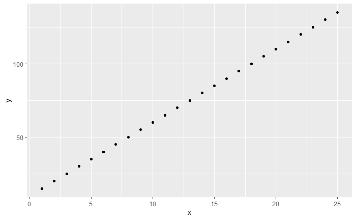

```r
x <- 1:25
y <- 10 + 5*x  # formula for a line
d <- data.frame(x, y)
ggplot(d) +
  aes(x, y) +
  geom_point()
```

10 is the y intercept, 5 is the slope. y is completely determined by x. That is, y = 10 + 5*x.

Now let’s add some “noise” to our data by adding random draws from a Normal distribution with mean = 0 and a standard deviation = 10. That’s what the `rnorm` function does.

`set.seed(1)` ensures we all generate the same “random” data:

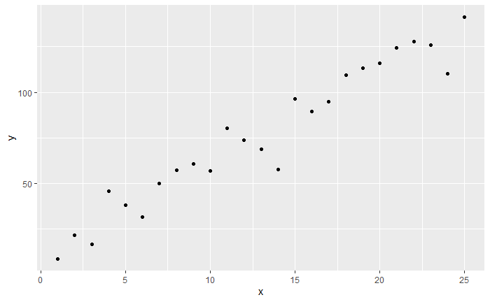

```r
set.seed(1)
noise <- rnorm(n = 25, mean = 0, sd = 10)
# Add the noise to 10 + 5*x and re-draw plot
d$y <- 10 + 5*x + noise
ggplot(d) +
  aes(x, y) +
  geom_point()
```

Now y appears to be *associated* with x, but not completely determined by x.

y is the combination of two parts:

1. 10 + 5*x *fixed*
2. rnorm(n = 25, mean = 0, sd = 10) *random*

What if we were given this data and told to determine the process that generated it? In other words, work backwards and fill in the blanks:

1. y = __ + __*x
2. rnorm(n = 25, mean = 0, sd = __)

*That’s one way to think of linear modeling/regression*. You have some numeric response (or dependent) variable, and you want to find the model (or the formula) that generated the data.

Traditional linear modeling/multiple regression assumes the following (among others):

1. the formula is a weighted sum of predictors (eg, y = 10 + 5*x)
2. the noise is a random draw from a Normal distribution with mean = 0
3. the standard deviation of the Normal distribution is constant (eg, 10)

Linear modeling tries to recover the weights in the first assumption and the standard deviation in the 3rd assumption.

Let’s attempt to recover the data generating process for our data. For this we use the `lm()` function. We have to specify the formula for the first assumption. The 2nd and 3rd assumptions are built into `lm()`.

The formula “y ~ x” means we think the model is “y = intercept + slope*x”. (Unless we specify otherwise, this assumes we want to estimate an intercept.) This tells `lm()` to take our data and find the best intercept and slope. *Notice this is the correct form of the model!*

When you use `lm` you’ll usually want to save the results to an object. Below I save it to “mod”. Then we view the results of the model using `summary()`

```r
mod <- lm(y ~ x, data = d)
summary(mod)
```

```
Call:
lm(formula = y ~ x, data = d)

Residuals:
    Min      1Q  Median      3Q     Max
-23.876  -4.613   2.254   5.909  14.648

Coefficients:
            Estimate Std. Error t value Pr(>|t|)
(Intercept)   11.135      3.999   2.784   0.0105 *
x              5.042      0.269  18.743 1.98e-15 ***
---
Signif. codes:  0 ‘***’ 0.001 ‘**’ 0.01 ‘*’ 0.05 ‘.’ 0.1 ‘ ’ 1

Residual standard error: 9.7 on 23 degrees of freedom
Multiple R-squared:  0.9386,    Adjusted R-squared:  0.9359
F-statistic: 351.3 on 1 and 23 DF,  p-value: 1.981e-15
```

The model returns the following estimates:

1. y = 11.135 + 5.042 * x
2. rnorm(n = 25, mean = 0, sd = 9.7)

These are pretty close to the “true” values of 10, 5, and 10 we used to generate the data.

**In real life, we DO NOT KNOW the formula in part 1. The real data generation process will be far more complicated. The formula we propose will just be an approximation and may not be good.**

**In real life, we DO NOT KNOW if the Normality assumption or constant variance assumption of the noise is plausible.**

How can we evaluate our model formula?

We could use our model estimates to generate data and see if they look similar to our original data. Feel free to repeatedly run the chunk to see different sets of model simulated data.

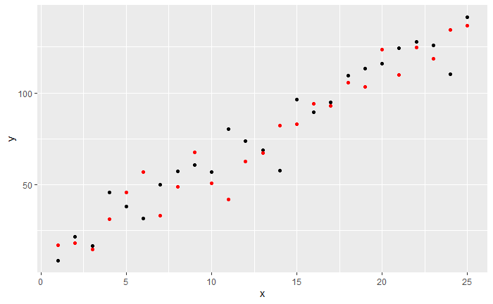

```r
# "observed" data:
# d$y <- 10 + 5*x + noise

# simulated data from fitted model
d$y2 <- 11.135 + 5.042*d$x + rnorm(25, 0, 9.7)
# plot(d$x, d$y)
# points(d$x, d$y2, col = "red")

ggplot(d) +
  geom_point(mapping = aes(x, y)) +
  geom_point(mapping = aes(x, y2), color = "red")
```

That looks pretty good! Our model-generated data appears similar to our observed data.

We could also compare smooth density curves of the original and model-generated data. Smooth density curves are basically smooth versions of histograms. If we have a good model, data generated by our model should have a similar distribution to the original data. (Run entire chunk at once.) Feel free to repeatedly run the chunk to see different sets of model simulated data.

```r
hist(d$y, freq = FALSE) # freq = FALSE means area of bars sums to 1
lines(density(d$y))
```

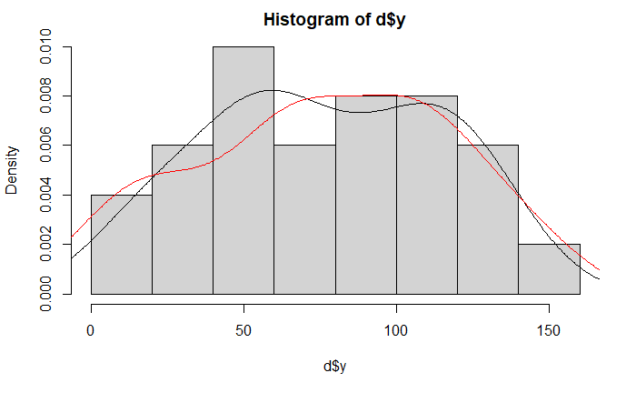

```r
d$y2 <- 11.135 + 5.042*d$x + rnorm(25, 0, 9.7)
lines(density(d$y2), col = "red")
```

This looks good as well. The distribution of our model-generated data is very similar to our observed data. You should do this more than once, say 50 times, to ensure the model consistently generates data similar to the observed data. We show one way to do that later in the presentation.

Since we think our model is “good”, we might use it to make a prediction. For example, when x = 10 what’s the expected value of y? Put another way, what’s the mean of y conditional on x = 10? We can do that with the `predict()` function. The `interval = "confidence"` arguments says return a 95% confidence interval (CI) for this mean.

```r
predict(mod, newdata = data.frame(x = 10), interval = "confidence")
```

```
       fit     lwr      upr
1 61.55932 57.2126 65.90603
```

The expected mean of y when x = 10 is about 61.6 with a 95% CI of (57.2, 65.9). The CI gives us some notion of how uncertain this expected mean is.

We might also try to summarize the relationship between y and x by examining the coefficients (or weights) in the summary output. We can extract the coefficients from the summary with the `coef()` function:

```r
coef(summary(mod))
```

```
             Estimate Std. Error   t value     Pr(>|t|)
(Intercept) 11.134859  3.9994866  2.784072 1.054874e-02
x            5.042446  0.2690346 18.742742 1.981382e-15
```

The x coefficient says that y increases by about 5 for every one-unit increase in x, give or take about 0.27. The standard error gives us some indication of the uncertainty in this estimate. We talk more about t values and p values below.

**TO SUMMARIZE: This is basic linear modeling:**

1. propose and fit a model
2. determine if the model is useful, is it “good”
3. use the model to explain relationships, provide advice, and/or make predictions

## CODE ALONG 1

Let’s see what happens when we fit a “bad” model. Below we simulate new set of data, like we did above, but this time we have a *non-linear* relationship.

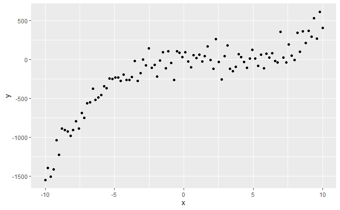

```r
x <- seq(-10, 10, length.out = 100)
y <- 2 + -2*x + -5*x^2 + 2+x^3
set.seed(11)
noise <- rnorm(n = 100, mean = 0, sd = 120)
d <- data.frame(x, y = y + noise)
ggplot(d) +
  aes(x, y) +
  geom_point()
```

1. Model `y` as a function of `x` using `lm(y ~ x, data = d)` and save to an object called `mod2`. View the summary. What formula does the model return? What is the estimated standard deviation of the Normally distributed noise?

```r
mod2 <- lm(y ~ x, data = d)
summary(mod2)
```

```
Call:
lm(formula = y ~ x, data = d)

Residuals:
    Min      1Q  Median      3Q     Max
-745.31 -152.67   30.96  191.10  484.14

Coefficients:
            Estimate Std. Error t value Pr(>|t|)
(Intercept) -180.855     24.704  -7.321 6.91e-11 ***
x             62.076      4.236  14.654  < 2e-16 ***
---
Signif. codes:  0 ‘***’ 0.001 ‘**’ 0.01 ‘*’ 0.05 ‘.’ 0.1 ‘ ’ 1

Residual standard error: 247 on 98 degrees of freedom
Multiple R-squared:  0.6866,    Adjusted R-squared:  0.6834
F-statistic: 214.7 on 1 and 98 DF,  p-value: < 2.2e-16
```

2. Use the summary results to generate a new set of data and name it “y2”. Then compare the smooth densities of the observed data and predicted data. How do they compare.

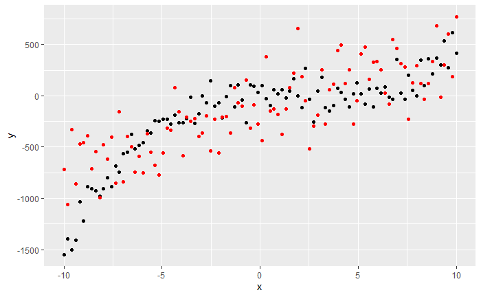

```r
d$y2 <- -180.855 + 62.076 * d$x + rnorm(100, 0, 247)
ggplot(d) +
  geom_point(mapping = aes(x, y)) +
  geom_point(mapping = aes(x, y2), color = "red")
```

We talk about fitting non-linear effects in the *Non-Linear Effects* section in the appendix.

Let’s do some linear modeling with real data.

## Import data

Let’s import our Albemarle County real estate data. We use the `readRDS()` function. Recall that an `rds` file is simply any R object that’s been saved. In this case we saved a data frame. Below we read in the rds file via URL. To do this we need to use the base R `url()` function to open a connection to the website where the file is stored.

```r
URL <- "https://github.com/uvastatlab/DJA/raw/main/data/albemarle_homes_2022.rds"
homes <- readRDS(url(URL))
```

Let’s look at the first few rows:

```r
head(homes)
```

|  | YearBuilt | YearRemodeled | Condition | FinSqFt | Cooling | FP_Open | Bedroom | FullBath | HalfBath | TotalRooms | LotSize | LandValue | ImprovementsValue | TotalValue | LastSalePrice | LastSaleDate | ESDistrict | MSDistrict | HSDistrict | CensusTract | Age | Remodeled | FP |
| --- | --- | --- | --- | --- | --- | --- | --- | --- | --- | --- | --- | --- | --- | --- | --- | --- | --- | --- | --- | --- | --- | --- | --- |
| 1 | 1939 | NA | Average | 1596 | No Central Air | 0 | 3 | 2 | 0 | 5 | 55.955 | 364700 | 219000 | 583700 | 1125000 | 04/23/2021 | Broadus Wood | Jouett | Albemarle | 101 | 83 | 0 | 0 |
| 2 | 1981 | NA | Average | 1616 | No Central Air | 1 | 6 | 4 | 0 | 9 | 5.167 | 137800 | 268300 | 406100 | 300000 | 03/23/2012 | Broadus Wood | Jouett | Albemarle | 101 | 41 | 0 | 1 |
| 3 | 1999 | NA | Average | 480 | No Central Air | 0 | 0 | 0 | 0 | 1 | 80.750 | 328000 | 29900 | 357900 | 0 | 03/18/2021 | Broadus Wood | Jouett | Albemarle | 101 | 23 | 0 | 0 |
| 4 | 1754 | NA | Very Poor | 836 | No Central Air | 0 | 1 | 0 | 0 | 3 | 80.718 | 343400 | 12100 | 355500 | 300000 | 02/16/2022 | Broadus Wood | Jouett | Albemarle | 101 | 268 | 0 | 0 |
| 5 | 1880 | NA | Fair | 1224 | No Central Air | 1 | 2 | 1 | 0 | 4 | 65.000 | 520000 | 128900 | 648900 | 0 | 03/20/2015 | Broadus Wood | Jouett | Albemarle | 101 | 142 | 0 | 1 |
| 6 | 1769 | 1988 | Average | 5216 | Central Air | 4 | 4 | 3 | 0 | 8 | 5.102 | 124500 | 1044700 | 1169200 | 0 | 06/02/2009 | Crozet | Henley | Western Albemarle | 101 | 253 | 1 | 1 |

Variable name definitions:

- *YearBuilt*: year house was built
- *YearRemodeled*: year house was remodeled
- *Condition*: assessed condition of home
- *FinSqFt*: finished square feet
- *Cooling*: Central Air indicator
- *FP_Open*: number of fireplaces
- *Bedroom*: number of bedrooms
- *FullBath*: number of full bathrooms (toilet, sink and bath)
- *HalfBath*: number of half bathrooms (toilet and sink only)
- *TotalRooms*: total rooms in house
- *LotSize*: size of land on which home is located, in acres
- *LandValue*: assessed value of the land
- *ImprovementsValue*: assessed value of “improvements” to lot
- *TotalValue*: total assessed value of home and property
- *LastSalePrice*: price of home when last sold
- *LastSaleDate*: date home was last sold
- *ESdistrict*: the elementary school the home feeds into
- *MSdistrict*: the middle school the home feeds into
- *HSDistrict*: the high school the home feeds into
- *CensusTract*: the census tract the home is located in
- *Age*: of the house in years as of 2022
- *Remodeled*: indicator if house has been remodeled (0=no, 1=yes)
- *FP*: indicator if house has fireplace (0=no, 1=yes)

## Linear Modeling with Real Estate Data

Let’s say we want to model the mean Total Value of a home as a function of various characteristics such as lot size, finished square feet, presence of central air, etc.

Let’s see how total value is distributed using a histogram. Notice it’s very skewed.

```r
hist(homes$TotalValue)
```

We can also create a smooth density plot, which is a smooth version of a histogram:

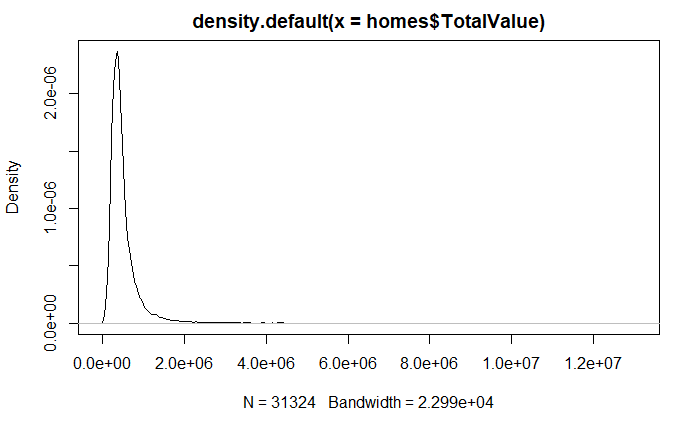

```r
plot(density(homes$TotalValue))
```

In order to model mean TotalValue of homes as a function of various characteristics, we need to propose a linear model. Unlike the previous example this is not simulated data for which we know the data generating process. How to propose a model? It helps to have some subject matter expertise.

Let’s fit a linear model using FinSqFt, Bedroom and LotSize. The plus (+) sign means “include” in model.

```r
m1 <- lm(TotalValue ~ FinSqFt + Bedroom + LotSize, data = homes)
summary(m1)
```

```
Call:
lm(formula = TotalValue ~ FinSqFt + Bedroom + LotSize, data = homes)

Residuals:
     Min       1Q   Median       3Q      Max
-2819156   -91573    -5843    66194  7426222

Coefficients:
              Estimate Std. Error t value Pr(>|t|)
(Intercept) -1.161e+05  5.538e+03  -20.96   <2e-16 ***
FinSqFt      3.279e+02  1.742e+00  188.23   <2e-16 ***
Bedroom     -2.785e+04  1.902e+03  -14.64   <2e-16 ***
LotSize      4.516e+03  6.662e+01   67.78   <2e-16 ***
---
Signif. codes:  0 ‘***’ 0.001 ‘**’ 0.01 ‘*’ 0.05 ‘.’ 0.1 ‘ ’ 1

Residual standard error: 249800 on 31320 degrees of freedom
Multiple R-squared:  0.6523,    Adjusted R-squared:  0.6522
F-statistic: 1.958e+04 on 3 and 31320 DF,  p-value: < 2.2e-16
```

The `coef()` function extracts the coefficients (or weights):

```r
coef(m1)
```

```
 (Intercept)      FinSqFt      Bedroom      LotSize
-116101.2400     327.8906  -27847.1711    4515.7094
```

Our proposed model is as follows:

$$\text{Mean TotalValue} = -116,101 + 327.9*\text{FinSqFt} +
-27,847*\text{Bedroom} + 4515*\text{LotSize}$$

Some naive interpretation:

- each additional finished square foot adds about $327 to total value
- each additional Bedroom drops the price by $27,847 (?)
- each additional acre of land adds about $4515 to price

The interpretation assumes *all other variables are held constant*! So adding a Bedroom to a house, without increasing the lot size or finished square feet of the house, is estimated to drop the value of a home. Does this make sense?

Is this a “good” model? Let’s simulate data from the model and compare it to our observed data. A “good” model should generate data that looks similar to the original data.

We could do this by hand:

```
sim_value <- -116101.2400  + 327.8906*homes$FinSqFt +
  -27847.1711*homes$Bedroom + 4515.7094*homes$LotSize +
  rnorm(nrow(homes), sd = 249800)
```

An easier and faster way is to use the `simulate()` function which allows you to generate multiple samples. Here we generate 50 samples. Each sample will have the same number of observations as our original sample (n = 31,324). Each sample value is generated using our observed values for `FinSqFt`, `Bedroom`, and `LotSize`. The result is a data frame with 50 columns.

```r
sim1 <- simulate(m1, nsim = 50)
```

Now let’s plot our simulated data with our observed data using smooth density plots. We use a for loop to add smooth density estimates of the 50 simulations. The syntax `sim1[[i]]` extracts column *i* as a vector. (Run entire chunk at once.)

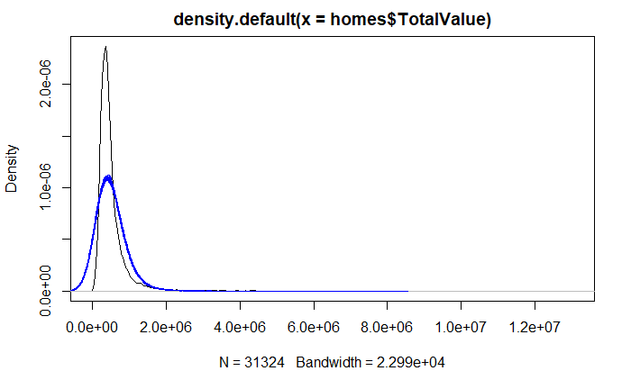

(See end of notebook for how to create this plot using ggplot2 and for how to turn this into a function.)

This does not appear to be a good model. In fact some of our simulated values are negative!

Another way to assess model fit is by plotting *fitted* values versus *residuals*. Residuals are the observed data minus the fitted data. We can get that plot by using the `plot()` function on our model and specifying `which = 1`. (There are six possible plots.)

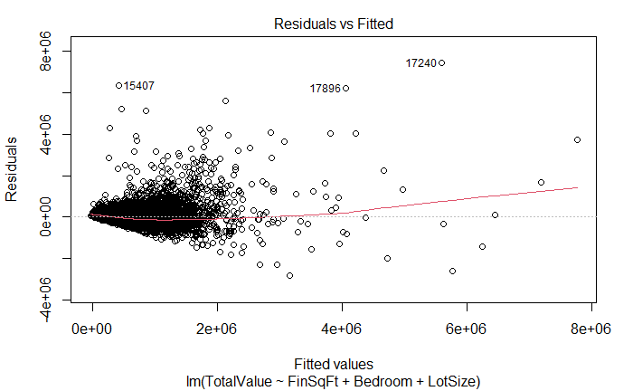

How to interpret plot:

- if a residual is 0, that means the model is perfectly fitting the true value.
- if a residual is positive, that means the observed value is *higher* than the fitted value. The model under predicts those values.
- if a residual is negative, that means the observed value is *lower* than the fitted value. The model over predicts those values.
- Ideally, residuals will be uniformly clustered around 0 (not the case in this plot!)

By default, the three most “extreme” values are labeled. The house in row 17240 has a fitted value of almost 6 million, but the residual is almost 8 million. This model way underfits this observation.

The observed value of this home is over 13 million.

```r
homes[17240, "TotalValue"]
```

```
[1] 13023600
```

This plot reveals that our assumption of a constant standard deviation is highly suspect. Non-constant standard deviation can be evidence of a wrong model or a very skewed response (or a bit of both). Recall that our response is quite skewed:

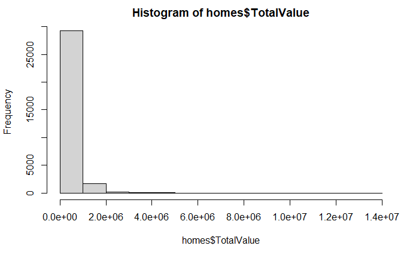

When dealing with a response that is strictly positive and very skew (like dollar amounts), it is common to transform the response to a different scale. A common transformation is a log transformation. When we log transform `TotalValue`, the distribution looks a little more symmetric, though it’s important to note that is not an assumption of linear modeling!

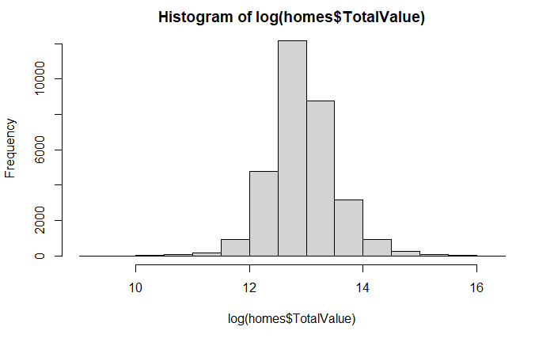

Let’s try modeling log-transformed `TotalValue`.

```r
m2 <- lm(log(TotalValue) ~ FinSqFt + Bedroom + LotSize, data = homes)
```

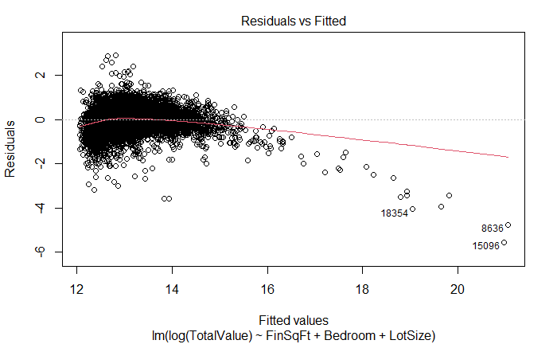

Let’s simulate data and compare to observed data.

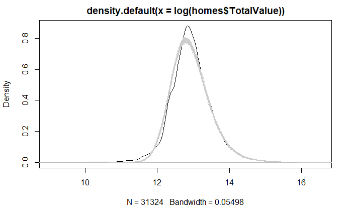

```r
sim2 <- simulate(m2, nsim = 50)
plot(density(log(homes$TotalValue)))
for(i in 1:50)lines(density(sim2[[i]]), lty = 2, col = "grey80")
```

This doesn’t look too bad!

Let’s say we’re happy with this model. How do we interpret the coefficients? Since the response is log transformed, we interpret the coefficients as *approximate proportional differences*. Below we view the coefficients rounded to 4 decimal places.

```r
round(coef(m2), 4)
```

```
(Intercept)     FinSqFt     Bedroom     LotSize
    11.8883      0.0004      0.0336      0.0031
```

These are proportions. To get percentages, multiply by 100.

```r
round(coef(m2), 4) * 100
```

```
(Intercept)     FinSqFt     Bedroom     LotSize
    1188.83        0.04        3.36        0.31
```

Some naive interpretations:

- each additional finished square foot increases price by 0.04%.
- each additional Bedroom increases price by about 3.36%
- each additional lot size acre increases price by about 0.31%

Remember, the interpretation assumes *all other variables are held constant*!

Increasing something by a percentage is a *multiplicative effect*.

- If everyone at a company gets a $100 raise, that’s additive.
- If everyone at a company gets a 3% raise, that’s multiplicative. We multiply the salary by 1.03 to get the new salary.

Let’s review the summary output:

```r
summary(m2)
```

```
Call:
lm(formula = log(TotalValue) ~ FinSqFt + Bedroom + LotSize, data = homes)

Residuals:
    Min      1Q  Median      3Q     Max
-5.5688 -0.1397  0.0182  0.1589  2.9018

Coefficients:
             Estimate Std. Error t value Pr(>|t|)
(Intercept) 1.189e+01  7.338e-03 1620.08   <2e-16 ***
FinSqFt     4.386e-04  2.308e-06  190.03   <2e-16 ***
Bedroom     3.357e-02  2.520e-03   13.32   <2e-16 ***
LotSize     3.135e-03  8.828e-05   35.52   <2e-16 ***
---
Signif. codes:  0 ‘***’ 0.001 ‘**’ 0.01 ‘*’ 0.05 ‘.’ 0.1 ‘ ’ 1

Residual standard error: 0.331 on 31320 degrees of freedom
Multiple R-squared:  0.6665,    Adjusted R-squared:  0.6664
F-statistic: 2.086e+04 on 3 and 31320 DF,  p-value: < 2.2e-16
```

SUMMARY OVERVIEW

- Estimate: coefficients for the model
- Std. Error: measures uncertainty of estimate.
- t value: Estimate/Std. Error (ratio)
- Pr(>|t|): Probability of t value that large or larger if coefficient = 0
- Residual standard error: estimate of the constant standard deviation of the normal dist’n of the residuals (noise)
- degrees of freedom: sample size (31324) - number of coefficients (4)
- R-squared: proportion of variance explained
- F-statistic: overall test that all coefficients (except intercept) are 0.

All of the p-values refer to hypothesis tests that the coefficients are 0. Many statisticians and researchers prefer to look at confidence intervals.

```r
round(confint(m2) * 100, 4)
```

```
                2.5 %    97.5 %
(Intercept) 1187.3893 1190.2658
FinSqFt        0.0434    0.0443
Bedroom        2.8629    3.8507
LotSize        0.2962    0.3308
```

According to our model, each additional Bedroom adds between 2.9% and 3.9% to the value of a home, assuming all else held constant.

## CODE ALONG 2

1. Insert a code chunk below and model `log(TotalValue)` as function of `FullBath` and `FinSqFt.` Call your model `m3`

```r
m3 <- lm(log(TotalValue) ~ FullBath + FinSqFt, data = homes)
```

2. Insert a code chunk below and check the Residuals vs Fitted plot

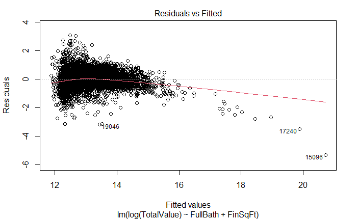

3. How do we interpret the FullBath coefficient?

```r
round(coef(m3), 3)
```

```
(Intercept)    FullBath     FinSqFt
     11.826       0.143       0.000
```

4. Insert a code chunk below and simulate data from the model and compare to the observed `TotalValue`. Does this look like a good model?

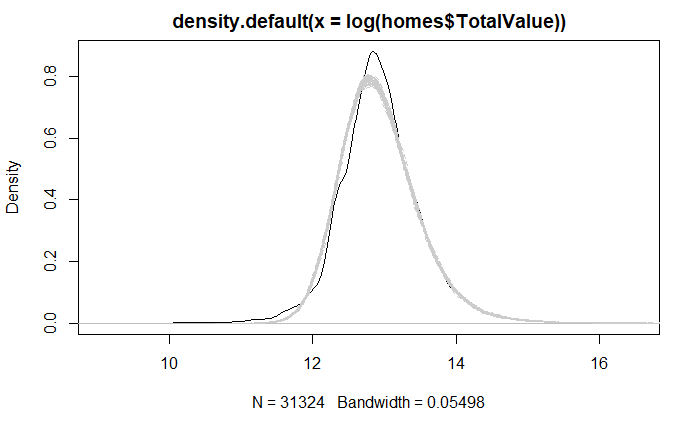

```r
sim3 <- simulate(m3, nsim = 50)
plot(density(log(homes$TotalValue)))
for(i in 1:50)lines(density(sim2[[i]]), lty = 2, col = "grey80")
```

## Categorical predictors

Let’s add `HSDistrict` to the model we just fit. Does being in a particular high school district affect total value of a home? Here’s a quick tally:

```r
table(homes$HSDistrict)
```

```
        Albemarle        Monticello Western Albemarle
            12164             10166              8994
```

HSDistrict does not contain numbers, it contains names. So how can we add it to a linear model? We use indicator variables. We’ll add two predictors to our model:

- Monticello
- Western Albemarle

We will indicate membership membership in HSDistrict as follows:

```
                  Monticello Western Albemarle
Albemarle                  0                 0
Monticello                 1                 0
Western Albemarle          0                 1
```

- a home in Albemarle HS district gets two zeroes
- a home in Monticello HS district gets a one in the Monticello column
- a home in Western Albemarle HS district gets a one in the West Alb column

Fortunately R takes care of this for us!

Let’s fit our new model. (Our model may not be right.)

```r
summary(m4)
```

```
Call:
lm(formula = log(TotalValue) ~ FullBath + FinSqFt + HSDistrict,
    data = homes)

Residuals:
    Min      1Q  Median      3Q     Max
-5.1222 -0.1445  0.0072  0.1472  3.1043

Coefficients:
                              Estimate Std. Error  t value Pr(>|t|)
(Intercept)                  1.182e+01  5.290e-03 2235.035  < 2e-16 ***
FullBath                     1.442e-01  2.625e-03   54.907  < 2e-16 ***
FinSqFt                      3.606e-04  2.558e-06  140.979  < 2e-16 ***
HSDistrictMonticello        -3.144e-02  4.294e-03   -7.323 2.48e-13 ***
HSDistrictWestern Albemarle  1.069e-01  4.500e-03   23.761  < 2e-16 ***
---
Signif. codes:  0 ‘***’ 0.001 ‘**’ 0.01 ‘*’ 0.05 ‘.’ 0.1 ‘ ’ 1

Residual standard error: 0.3186 on 31319 degrees of freedom
Multiple R-squared:  0.6911,    Adjusted R-squared:  0.691
F-statistic: 1.752e+04 on 4 and 31319 DF,  p-value: < 2.2e-16
```

The coefficients for Monticello and Western Albemarle are in relation to Albemarle HS.

```r
round(coef(m4),4) * 100
```

```
                (Intercept)                    FullBath
                    1182.25                       14.42
                    FinSqFt        HSDistrictMonticello
                       0.04                       -3.14
HSDistrictWestern Albemarle
                      10.69
```

It appears that the value of a home in Western Albemarle will be about 11% higher than an equivalent home in Albemarle. Likewise it appears that the value of a home in the Monticello district will be about 3% less than an equivalent home in the Albemarle district.

## CODE ALONG 3

1. Insert a code chunk below and model `log(TotalValue)` as function of `FullBath`, `FinSqFt` and `Cooling.` Call your model `m5`.

```r
m5 <- lm(log(TotalValue) ~ FullBath + FinSqFt + Cooling, data = homes)
```

2. What is the interpretation of Cooling? What is the baseline or reference level?

```r
round(coef(m5), 4) * 100
```

```
       (Intercept)           FullBath            FinSqFt CoolingCentral Air
           1168.17              11.85               0.04              22.90
```

## Modeling Interactions

In our model above that included `HSDistrict` we assumed the effects were *additive*. For example, it didn’t matter what high school district your home was in, the effect of `FullBath` or `FinSqFt` was the same. It also assumed the effect of each additional `FullBath` was the same regardless of how big the house was, and vice versa. This may be too simple.

Interactions allow the effects of variables to depend on other variables. Again subject matter knowledge helps with the proposal of interactions. As we’ll see interactions make your model more flexible but harder to understand.

R makes it simple to include interactions in models. Just indicate an interaction between two variables by placing a colon (:) between them. Below we include 2-way interactions. (You can have 3-way and higher interactions but they’re very difficult to interpret.)

```r
m6 <- lm(log(TotalValue) ~ FullBath + FinSqFt + HSDistrict +
           FullBath:FinSqFt + FullBath:HSDistrict +
           FinSqFt:HSDistrict, data = homes)
summary(m6)
```

Interpretation is now much more difficult. We cannot directly interpret the *main effects* of `FullBath`, `FinSqFt` or `HSDistrict`. They interact. What’s the effect of `FinSqFt`? It depends on `FullBath` and `HSDistrict`.

Are the interactions “significant” or necessary? Use the `anova` function to evaluate this question:

```r
anova(m6)
```

Just because an interaction is significant doesn’t necessarily mean it’s interesting or worthwhile. Nor can we infer anything about the nature of the interaction from the ANOVA table.

*Effect plots* can help us visualize and make sense of models with interactions. Let’s make one using the ggeffects package and talk about what it’s showing.

```r
library(ggeffects)
plot(ggpredict(m6, terms = c("FullBath", "HSDistrict")))
# place FullBath on x-axis, group by HSDistrict
```

What exactly was plotted? We can see by calling `ggpredict` without `plot`

```r
ggpredict(m6, terms = c("FullBath", "HSDistrict"))
```

We can specify our values if we like. For example, make an effect plot for 1 - 5 bathrooms and hold `FinSqFt` at 2000:

```r
plot(ggpredict(m6, terms = c("FullBath[1:5]", "HSDistrict"),
          condition = c(FinSqFt = 2000)))
```

What about the effects of `FinSqFt` and `FullBath`? This is an interaction of two numeric variables. The second variable has to serve as a grouping variable when creating an effect plot. Below we set `FullBath` to take values 2 - 5 and `FinSqFt` to take values of 1000 - 4000 in steps of 500.

```r
plot(ggpredict(m6, terms = c("FinSqFt[1000:4000 by=500]", "FullBath[2:5]")))
```

## CODE ALONG 4

1. Insert a code chunk below and model `log(TotalValue)` as function of `FullBath`, `FinSqFt`, `Cooling`, and the interaction of `FinSqFt` and `Cooling`. Call your model `m7`. Is the interaction warranted?

```r
m7 <- lm(log(TotalValue) ~ FullBath + FinSqFt + Cooling + FinSqFt:Cooling,
         data = homes)
anova(m7)
```

2. Visualize the interaction using the `ggpredict` function. Perhaps use `[1000:4000 by=500]` to set the range of `FinSqFt` on the x-axis.

```r
plot(ggpredict(m7, terms = c("FinSqFt[1000:4000 by=500]", "Cooling")))
```

## Wrap-up

This was meant to show you the basics of linear modeling in R. Hopefully you have a better grasp of how linear modeling works.

What we did today works for *independent, numeric outcomes*. We had one observation per home and our response was `TotalValue`, a number. Our models returned expected *mean* total value given various predictors. This is a pretty simple design.

Things get more complicated when you have, say, binary responses or multiple measures on the same subject (or home). A non-exhaustive list of other types of statistical modeling include:

- generalized linear models (for binary and count responses)
- multinomial logit models (for categorical responses)
- ordered logit models (for ordered categorical responses)
- mixed-effect or longitudinal linear models (for responses with multiple measures on the same subject or clusters of related measures)
- survival models (for responses that measure time to an event)
- time series models (for responses that exhibit, say, seasonal variation over time)

**References**

- Faraway, J. (2005). *Linear Models in R*. London: Chapman & Hall.
- Fox, J. (2002). *A R and S-Plus Companion to Applied Regression*. London: Sage.
- Harrell, F. (2015). *Regression Modeling Strategies* (2nd ed.). New York: Springer.
- Kutner, M., et al. (2005). *Applied Linear Statistical Models* (5th ed.). New York: McGraw-Hill.
- Maindonald J., Braun, J.W. (2010). *Data Analysis and Graphics Using R* (3rd ed.). Cambridge: Cambridge Univ Press.

## Nonlinear Effects

So far we have assumed that the relationship between a predictor and the response is linear (eg, for a 1-unit change in a predictor, the response changes by a fixed amount). That assumption can sometimes be too simple and not realistic. Fortunately there are ways to fit non-linear effects in a linear model.

Here’s a quick example of simulated non-linear data: a 2nd degree polynomial.

```r
x <- seq(from = -10, to = 10, length.out = 100)
set.seed(3)
y <- 1.2 + 2*x + 0.9*x^2 + rnorm(100, sd = 10)
nl_dat <- data.frame(y, x)
plot(y ~ x, nl_dat)
```

Clearly a straight-line model will not work for this data. The relationship between x and y is not adequately summarized by a straight line model.

If we wanted to try to “recover” the weights we used in simulating this data we could fit a polynomial model:

```
## EXAMPLE CODE; NOT INTENED TO BE RUN
nlm1 <- lm(y ~ poly(x, degree = 2, raw = TRUE), data = nl_dat)
```

However, the recommended approach to fitting non-linear effects is to use *natural splines* instead of polynomials. Natural splines essentially allow us to fit a series of cubic polynomials connected at knots located in the range of our data.

The easiest option is to use the `ns()` function from the splines package. `ns` stands for “natural splines”. The second argument is the degrees of freedom (`df`). It may help to think of `df` as the number of times the smooth line changes directions.

Frank Harrell states in his book *Regression Model Strategies* that 3 to 5 `df` is almost always sufficient. His basic advice is to allocate more `df` to variables you think are more important.

Let’s see how it works with our simulated data.

```r
library(splines)
nlm2 <- lm(y ~ ns(x, df = 2), data = nl_dat)
```

Here’s one way to see the fitted line.

```r
plot(ggpredict(nlm2, terms = "x"), add.data = TRUE)
```

Let’s return to the homes data and fit a non-linear effect for `FinSqFt` using a natural spline with 5 `df`. Below we also include `HSDistrict` and `LotSize` and allow `FinSqFt` and `HSDistrict` to interact.

```r
nlm3 <- lm(log(TotalValue) ~ ns(FinSqFt, 5) + HSDistrict + LotSize +
           ns(FinSqFt, 5):HSDistrict,
         data = homes)
```

The `anova` function allows us to assess the non-linear effect and the interaction:

```r
anova(nlm3)
```

The summary output is impossible to interpret.

```r
summary(nlm3)
```

Effect plots are our only hope for understanding this model.

```r
plot(ggpredict(nlm3, terms = c("FinSqFt[1000:3000 by=250]", "HSDistrict")))
```

Does the model simulate data similar in distribution to the observed data?

```r
sim4 <- simulate(nlm3, nsim = 50)
plot(density(log(homes$TotalValue)))
for(i in 1:50)lines(density(sim4[[i]]), col = "grey80")
```

We should still check model assumptions of constant variance and normal residuals.

```r
plot(nlm3)
```

```r
h <- c(13276, 15097, 19047, 19941, 24355, 17241)
homes[h,c("TotalValue", "FinSqFt", "LotSize")]
```

- Homes 13276, 19047 and 19941 have tiny TotalValues relative to their FinSqFt. Are these typos?
- Home 24355 has an enormous LotSize!
- Homes 17241 and 15097 have massive FinSqFt values.

```r
cbind(obs = homes$TotalValue[h], fit = exp(fitted(nlm3)[h]))
```

## CODE ALONG 5

1. Insert a code chunk below and model `log(TotalValue)` as function of `FinSqFt` with a natural spline of 5 `df`, `Cooling`, and the interaction of `Cooling` and `FinSqFt` (natural spline of 5 `df`). Call your model `nlm4`.
2. Use the `anova` function to check whether the interaction appears necessary. What do you think?
3. Create an effect plot of `FinSqFt` by `Cooling`. Maybe try `[1000:5000 by=250]` for the range of values for `FinSqFt`.
4. Check the graphical model assumptions using the `plot` function.
5. How well does the distribution of the model-generated data match the distribution of the observed data?

## ggplot2 code for creating plot of simulated data

Here’s how to make the simulation plot using ggplot2. I find base R graphics easier for this type of plot.

```r
library(ggplot2)
library(tidyr)
sim1 %>%
  pivot_longer(everything(),
               names_to = "simulation",
               values_to = "TotalValue") %>%
  ggplot() +
  geom_density(mapping = aes(x = TotalValue, group = simulation),
               color = "grey80") +
  geom_density(mapping = aes(x = TotalValue),
               data = homes)
```

## How to make a function for simulating and plotting data for a linear model

**Base R**

We basically copy and paste the original code in between the curly braces of the `function()` function. We call the function `plot_sims` but you can name it whatever you like. The changes are to the model name and number of simulations. We generalize those with arguments: `mod` and `nsim`. When we fit a model with `lm`, the data is stored with the model object by default and can be accessed as mod$model. The first column contains the model response, so we can access it with `[,1]` and use it to draw the density of the observed data.

```r
# ORIGINAL CODE

# sim1 <- simulate(mod, nsim = 50)
# plot(density(homes$TotalValue))
# for(i in 1:50)lines(density(sim1[[i]]), col = "grey80")

plot_sims <- function(mod, nsim){
  sim1 <- simulate(mod, nsim = nsim)
  plot(density(mod$model[,1]))
  for(i in 1:nsim)lines(density(sim1[[i]]), col = "grey80")
}
# try the function
plot_sims(m1, nsim = 20)
```

**ggplot2**

Same idea as the previous function: we want to copy the original code in between the curly braces of the `function()` function. Except we now want to preface functions with their package name (eg, ggplot2::) so we can use the function without having the packages loaded. We also do away with the pipe `%>%` since it comes from yet another package (magrittr) but is accessible when tidyr is loaded. We extract the name of the response using `resp <- names(mod$model)[1]` and then use the use the `.data` pronoun (`.data[[resp]]`) from rlang package to use it with ggplot.

```r
## ORIGINAL CODE

# library(ggplot2)
# library(tidyr)

# sim1 <- simulate(mod, nsim = 50)
# sim1 %>%
#   pivot_longer(everything(),
#                names_to = "simulation",
#                values_to = "TotalValue") %>%
#   ggplot() +
#   geom_density(mapping = aes(x = TotalValue, group = simulation),
#                color = "grey80") +
#   geom_density(mapping = aes(x = TotalValue),
#                data = homes)

plot_sims <- function(mod, nsim){
  sim1 <- simulate(mod, nsim = nsim)
  resp <- names(mod$model)[1]
  sim1 <- tidyr::pivot_longer(sim1, everything(),
               names_to = "simulation",
               values_to = "TotalValue")
  ggplot2::ggplot() +
  ggplot2::geom_density(mapping = ggplot2::aes(x = TotalValue,
                                               group = simulation),
                        color = "grey80",
                        data = sim1) +
  ggplot2::geom_density(mapping = ggplot2::aes(x = .data[[resp]]),
                        data = mod$model)
}

plot_sims(m1, nsim = 65)
```

Finally, the bayesplot package has a function for this called `ppc_dens_overlay`, but it’s a little weird to use for linear models because it was designed to be used with Bayesian models. However it’s not that hard to deploy. The first argument is simply the observed data. The second argument expects the simulations per row as opposed to per column. So we need to transpose, which we can do with the `t` function. The result is a clean plot with the y-axis unlabeled since it really isn’t needed and a legend to distinguish between observed and simulated (or replicated) data.

```r
# install.packages("bayesplot")
library(bayesplot)
ppc_dens_overlay(homes$TotalValue, t(sim1))
```